# STAT 428: Homework 4: Chapter 6 Monte Carlo Methods in Inference

Du, Yuting, yutingd3 Collaborated with: Sun, Yifan, yifans8

Please refer to the [**detailed homework policy document**] on Course Page for information about homework formatting, submission, and grading.

## Exercise 1

**An Exploration of Standard Error in Monte Carlo Estimation**

Consider the following integral:
$$\int_0^{1}{\frac{\ln{(x+1)}}{\pi\sqrt{x(1-x)}}}dx.$$

1. Estimate the integral using naive Monte Carlo. What is the standard error of this estimate?

```r
u = runif(1000)
I0 = mean(log(u+1)/(pi*sqrt(u*(1-u))))
I0
```

```
## [1] 0.376
```

```r
x = numeric()
for(i in 1:1000){
  x[i] = mean(log(u[i]+1)/(pi*sqrt(u[i]*(1-u[i]))))
}
E0 = sd(x)/sqrt(1000)
E0
```

```
## [1] 0.01762
```

2. Let’s see if we can improve the standard error. Implement Monte Carlo with antithetic sampling to estimate this integral. What is the standard error of this estimate?

```r
I1 = numeric()
I11 = numeric()
I12 = numeric()


for(i in 1:1000){
  k1 <- 500
  u1 <- runif(500)
  I11[i] <-  mean(log(u[i]+1)/(pi*sqrt(u[i]*(1-u[i]))))

  k2 <- 500
  u2 <- runif(500)
  I12[i] <-  mean(log(1-u[i]+1)/(pi*sqrt(u[i]*(1-u[i]))))


  I1[i] <- (I11[i] + I12[i])/2
}

E1 <- sd(I1)/sqrt(1000)
E1
```

```
## [1] 0.009745
```

3. Would stratified sampling seem to help here? Why or why not? (Whatever you decide, you do not need to implement it).

I believe that stratified sampling will also work in reducing the standard error. It uses simaple random sampling from uniform distributions but stratify these to ensure balance over a partition into k subintervals of (0, 1)

4. $f(x)=\frac{1}{\pi\sqrt{x(1-x)}}$ for $x\in(0,1)$ is the probability density function for the [Arcsine distribution](https://en.wikipedia.org/wiki/Arcsine_distribution). Using inverse transformation method, sample 1000 random values from the Arcsine distribution.

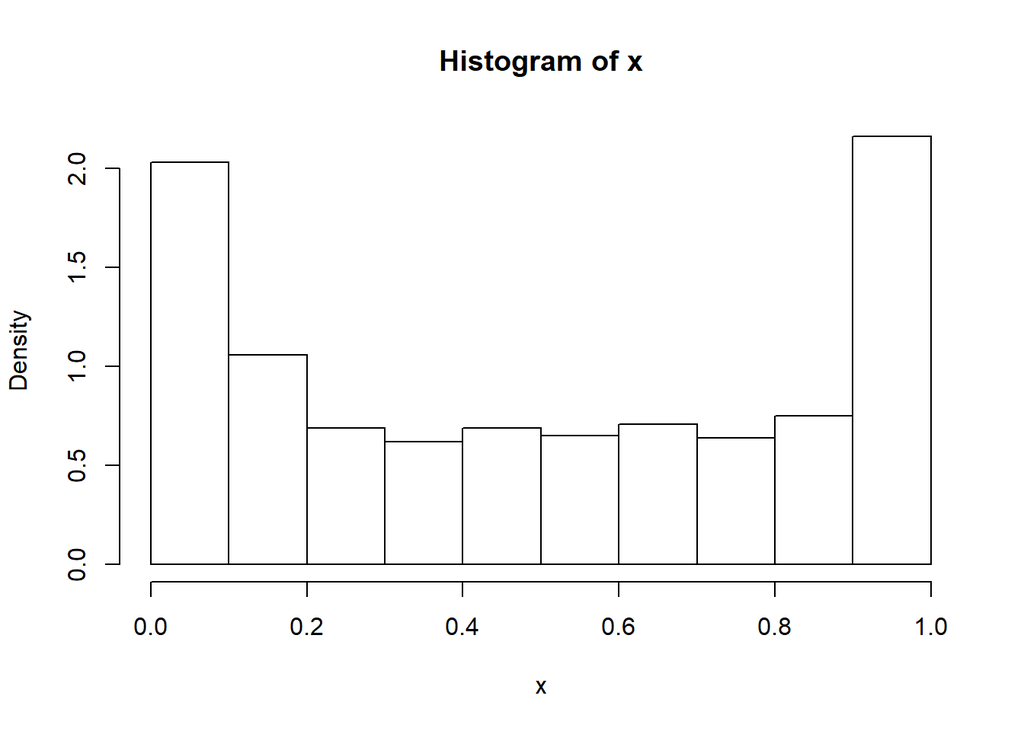

5. Use importance sampling and the code you wrote in part d to estimate this integral. What is the standard error?  
   The importance function we choose is the pdf of Arcsine distribution.

```r
m = 1000

gf = function(x){
  g = log(x+1)/(pi*sqrt(x*(1-x)))
  f = (x<1)*(x>0)
  g*f
}

##try our importance function
u = runif(m)
x = (sin(pi*u/2))^2
gfphi = gf(x)*(pi*sqrt(x*(1-x)))
E2 = sd(gfphi)/sqrt(m)
E2
```

```
## [1] 0.007744
```

6. Are all methods equally effective? Which method is the most efficient?

No. It seems like importance sampling is the most efficient way to reduce the error variance.

## Exercise 2

**Comparing MSE of estimators using MC.**

Let $f(x|\theta) = \mathrm{t}(\nu,\mu)$, the [non-central t-distribution](https://en.wikipedia.org/wiki/Noncentral_t-distribution), where $\mu$ is a location parameter and $\nu$ is the degrees of freedom.

Estimate the MSE of the level k trimmed means for random samples of size 20 generated from a a non-central t-distribution with degrees of freedom 3 and mean 4 (with $\nu = 3$ and $\mu=4$). Summarize the estimates of MSE in a table for k = 1, 2, … , 9.

```r
n = 20
K = n/2 - 1
m = 1000
mse = matrix(0, n/2, 2)

trimmed.mse = function(n, m, k){
  tmean = numeric(m)
  for(i in 1:m){
    x = sort(rt(m, 3, 4))
    tmean[i] = mean(x[(k+1):(n-k)])
  }
  mse.est = mean(tmean^2)
  se.mse = sqrt(mean((tmean - mean(tmean))^2))/sqrt(m)
  return (c(mse.est, se.mse))
}

for(k in 1:K){
  mse[k, 1:2] = trimmed.mse(n,m,k)
}

round(mse, 3)
```

```
##        [,1]  [,2]
##  [1,] 1.887 0.003
##  [2,] 1.935 0.003
##  [3,] 1.930 0.003
##  [4,] 1.956 0.003
##  [5,] 1.971 0.003
##  [6,] 2.001 0.003
##  [7,] 1.995 0.003
##  [8,] 1.999 0.003
##  [9,] 2.000 0.003
## [10,] 0.000 0.000
```

## Exercise 3

**Bayesian Statistics** Suppose $X_1,\ldots,X_n$ are $n$ independent and identical distributed random variables from $Exp(\theta)$, where $\theta$ is the unknown parameter. So,
$$f(x|\theta) = \theta \; e^{-\theta x}, \quad x \ge 0.$$

We assume the prior distribution on $\theta$ is the Gamma distribution ($Gamma(3,2)$).
$$g(\theta) = 4 \theta^2 e^{-2\theta}, \quad x \ge 0.$$

1. Write down the posterior distribution of $\theta$, $g(\theta|X)$.

$$g(\theta|x) = {\frac{L(\theta)g(\theta)}{C}}$$
where,
$$L(\theta) = {\prod_{n=1}^{n} f(x_i|\theta)}$$
and
$$g(\theta|x) = \int{\prod_{n=1}^{n} f(x_i|\theta)g(\theta)}dx$$

2. Suppose $n=6$ and we observe that $x_1=0.4, x_2=1.1, x_3=0.2, x_4=1.6, x_5=1.4, x_6=0.9$. Estimate the posterior mean of $\theta$ based on $1000$ simulated $\theta$ from its prior distribution.

```r
observed_x = c(0.4, 1.1, 0.2, 1.6, 1.4, 0.9)

hx = numeric()
post.mean = numeric()
for(i in 1:length(observed_x)){
theta = rgamma(n = 1000, shape = 3, rate = 2)
hx[i] = theta*exp(-theta*observed_x[i])
c = mean(hx)
post.mean[i] = mean(theta*hx)/c
}
cbind(observed_x,post.mean)
```

```
##      observed_x post.mean
## [1,]        0.4     1.497
## [2,]        1.1     1.506
## [3,]        0.2     1.555
## [4,]        1.6     1.516
## [5,]        1.4     1.525
## [6,]        0.9     1.472
```

3. Suppose $n=6$ and we observe that $x_1=0.4, x_2=1.1, x_3=0.2, x_4=1.6, x_5=1.4, x_6=0.9$.
   1. Design an acceptance-rejection sampling algorithm to generate $1000$ (accepted) samples of $\theta$ from the posterior distribution of $\theta$. Write down your algorithm with your instrumental distribution $g(\theta)$. (Hint: for the acceptance-rejection sampling method, the normalizing constant in the posterior distribution can be ignored.)

Given that M = 0.5, for each observed x do folowing steps 1. generate 1 sample form gamma(3, 2) as the theta 2. generate 1 sample from uniform(1) 3. calculate f(x|theta) based on the observed x and theta from 1 4. calculate g(x) based on the observed x 5, Test uf the sample from 2 less than f(x|theta) / (M*g(x)) accept theta from 1 repeat until get 1000 accepted theta

2. Implement your acceptance-rejection sampling algorithm with R code. Plot the histogram of your generated sample and compare your sample mean with your estimated posterior mean obtained in Ex.3.2.

```r
observed_x = c(0.4, 1.1, 0.2, 1.6, 1.4, 0.9)

fx = function(theta, x){
  theta*exp(-theta*x)*4*(theta^2)*exp(-2*theta)
}
AR = function(x, n){
  i = 0
  theta = numeric()
  M = 0.5
  while (i < n) {
    theta0 = rgamma(1,shape = 3, rate = 2)
    u = runif(1)
    if(M*u < fx(theta0, x)/dgamma(x, shape = 3, rate = 2)){
      i = i + 1
      theta[i] = theta0
    }
  }
  return(theta)
}
x = c(0.4,1.1,0.2,1.6,1.4,0.9)
AR(x = x, n = 6)
```

```
## [1] 1.7378 0.6562 0.7857 1.1642 2.4437 1.6036
```

## Exercise 4

Do 6.1 in the book, except with $n=25$ and $k=1,2,\cdots,10$.

```r
m <- 2000
K <- 10
n <- 25
tmean <- matrix(0,m,K)
mse_est <- numeric(K)
mse_se <- numeric(K)
for(k in 1:K){
  for (i in 1:m) {
    x <- sort(rcauchy(n))
    tmean[i,k] <- mean(x[(k+1):(n-k)])
    }
  mse_est[k] <- mean(tmean[,k]^2)
  mse_se[k] <- sqrt(sum((tmean[,k] - mean(tmean[,k]))^2)) / m
}
table <- cbind(seq(1:K),round(mse_est,5),round(mse_se,5))
colnames(table) <- c("k", "Estimated MSE of level k trimmed means", "Standard Error")
knitr::kable(table, caption = 'Estimates of MSE')
```

Estimates of MSE

| k | Estimated MSE of level k trimmed means | Standard Error |
| --- | --- | --- |
| 1 | 1.2145 | 0.0246 |
| 2 | 0.4213 | 0.0145 |
| 3 | 0.2382 | 0.0109 |
| 4 | 0.1645 | 0.0091 |
| 5 | 0.1400 | 0.0084 |
| 6 | 0.1189 | 0.0077 |
| 7 | 0.1152 | 0.0076 |
| 8 | 0.1039 | 0.0072 |
| 9 | 0.1116 | 0.0075 |
| 10 | 0.1007 | 0.0071 |

## Exercise 5

Do exercise 6.2 from the book.

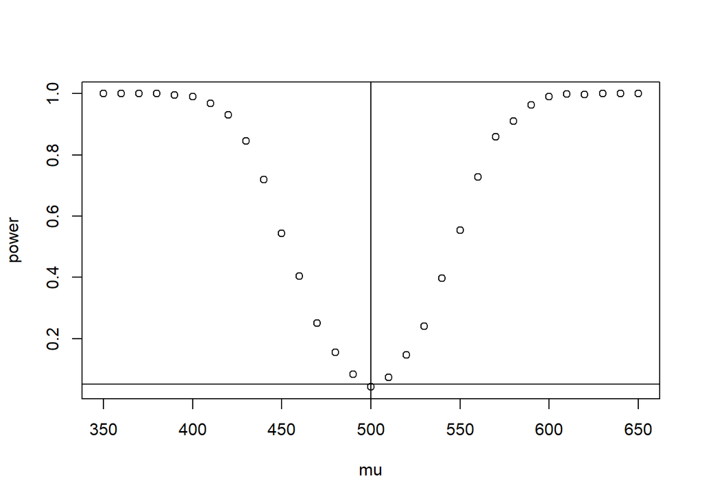

```r
library(Hmisc) #for errbar

alpha = 0.05
mu <- c(seq(350, 650, 10)) #alternative H
n <- 20
sigma <- 100
m <- 1000
mu0 <- 500
M <- length(mu)
power <- numeric(M)
for (i in 1 : M) {
  pvalues <- replicate(m, expr = {x <- rnorm(n, mean = mu[i], sd = sigma)
      ttest <- t.test(x, alternative = "two.sided", mu = mu0)
      ttest$p.value})
  power[i] <- mean(pvalues <= alpha)
}

plot(mu, power)
abline(v = mu0, lty = 1)
abline(h = alpha, lty = 1)
```

## Exercise 6

Do exercise 6.3 from the book.

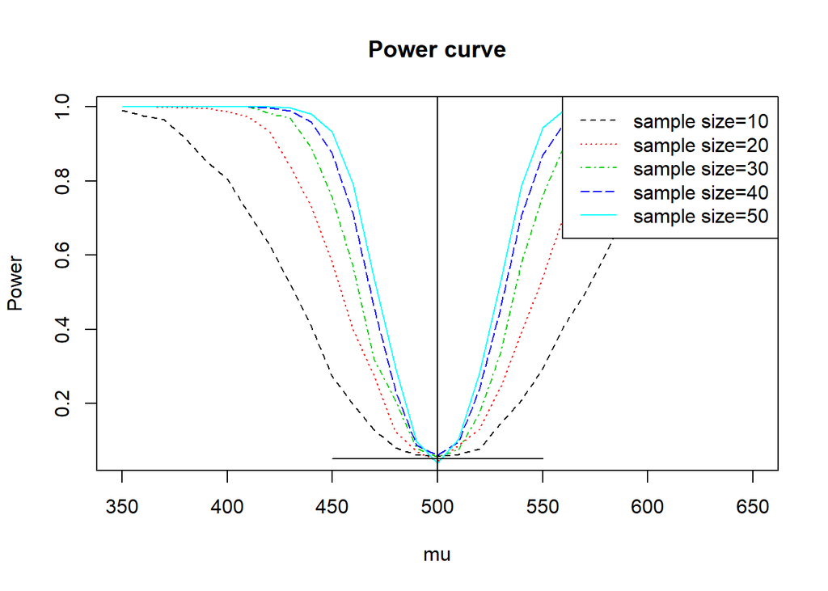

```r
n <- seq(10,50,10) #sample size
mu <- c(seq(350, 650, 10))
m <- 1000
M <- length(mu)
N <- length(n)
power <- matrix(0,M,N)
for(j in 1:N){
  for (i in 1:M){
    mu1 <- mu[i]
    pvalues <- replicate(m, expr = {
      #simulate under alternative mu1
      x <- rnorm(n[j], mean = mu1, sd = 100)
      ttest <- t.test(x,
      alternative = "two.sided", mu = 500)
      ttest$p.value })
    power[i, j] <- mean(pvalues <= .05)
  }
}
plot(mu, power[,1], type="l", lty = 2, col = 1, main="Power curve", xlab="mu", ylab="Power")
lines(mu, power[,2], lty = 3, col = 2)
lines(mu, power[,3], lty = 4, col = 3)
lines(mu, power[,4], lty = 5, col = 4)
lines(mu, power[,5], lty = 1, col = 5)
legend("topright", c("sample size=10","sample size=20","sample size=30","sample size=40","sample size=50"), lty = c(2,3,4,5,1),col=c(1,2,3,4,5))
abline(v = 500, lty = 1)
lines(c(450,550),c(0.05,0.05))
```

## Exercise 7

Do exercise 6.5 from the book.

```r
alpha <- 0.05
m <- 1000
n <- 20
qt <- qt(1-alpha/2, df = n-1)
LCL <- replicate(m, expr = {
  x <- rchisq(n, 2)
  return(mean(x) - qt * sd(x) / sqrt(n))
})
UCL <- replicate(m, expr = {
  x <- rchisq(n, 2)
  return(mean(x) + qt * sd(x) / sqrt(n))
})
mean((LCL < 2) * (UCL > 2))
```

```
## [1] 0.926
```

## Exercise 8

Do exercise 6.8 from the book. Use 15 as small sample size, 50 as medium sample size, and 250 as large sample size.

```r
alpha = 0.055
mu1 <- mu2 <- 0
sigma1 <- 1
sigma2 <- 1.5
sample_num <- c(15, 50, 250)

m <- 1000
tests_F <- numeric(3)
tests_CF <- numeric(3)

testF <- function(x, y) {
  f_test <- var.test(x, y, alternative = "two.sided", conf.level = 1-alpha)
  return(f_test$p.value < alpha)
}
tests5 = function(X, Y) {
  outx <- sum(X > max(Y)) + sum(X < min(Y))
  outy <- sum(Y > max(X)) + sum(Y < min(X))
  return(as.integer(max(c(outx, outy)) > 5))
}
for (i in 1 : 3) {
  n <- sample_num[i]
  power_F <- mean(replicate(m, expr = {
  x <- rnorm(n, mu1, sigma1)
  y <- rnorm(n, mu2, sigma2)
  testF(x, y)
}))
  power_CF <- mean(replicate(m, expr = {
  x <- rnorm(n, mu1, sigma1)
  y <- rnorm(n, mu2, sigma2)
  tests5(x, y)
}))

  tests_F[i] <- power_F
  tests_CF[i] <- power_CF
}

(table = rbind(tests_F, tests_CF))
```

```
##           [,1]  [,2]  [,3]
## tests_F  0.339 0.807 1.000
## tests_CF 0.273 0.661 0.965
```